# Asssignment: Machine Learning

# Q16. A bar chart showing the count of approved vs rejected loans. & Commentation on the balance.

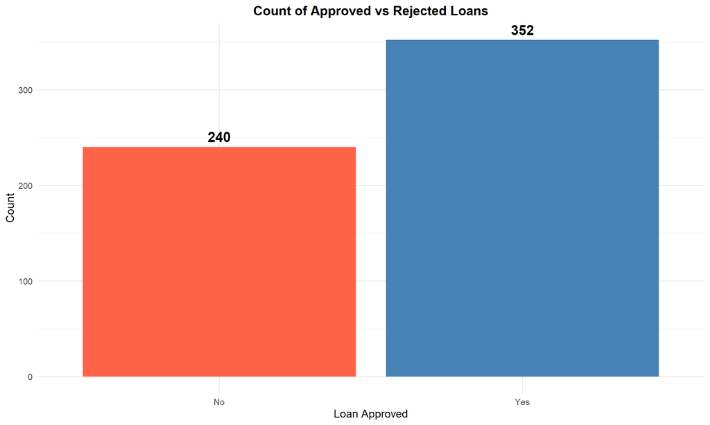

```r
ggplot(data, aes(x = Loan_Approved, fill = Loan_Approved)) + geom_bar() + geom_text(stat = "count",
    aes(label = after_stat(count)), vjust = -0.5, size = 5, fontface = "bold") +
    scale_fill_manual(values = c(No = "tomato", Yes = "steelblue")) + labs(title = "Count of Approved vs Rejected Loans",
    x = "Loan Approved", y = "Count", fill = "Loan_Approved") + theme_minimal() +
    theme(legend.position = "none", plot.title = element_text(hjust = 0.5, face = "bold"))
```

- The bar chart of Loan_Approved shows 352 approved loans (59.5%) and 240 rejected loans (40.5%), giving a majority-to-minority ratio of 1.47 : 1. The minority class accounts for more than 40% of the data, and the ratio sits below the conventional 1.5 : 1 threshold, so the dataset is approximately balanced.

# Q17: Heatmap

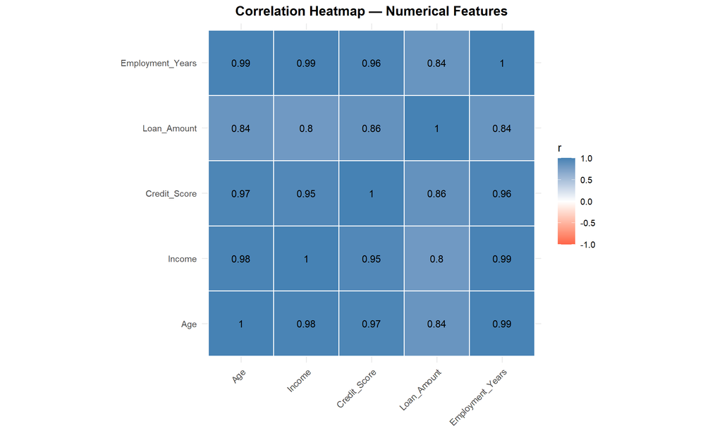

```r
cor_mat <- cor(data[num_var])
melted <- melt(cor_mat)
melted$Var1 <- factor(melted$Var1, levels = num_var)
melted$Var2 <- factor(melted$Var2, levels = num_var)
ggplot(melted, aes(x = Var1, y = Var2, fill = value)) + geom_tile(colour = "white",
    linewidth = 0.5) + geom_text(aes(label = round(value, 2)), size = 3.5, colour = "black") +
    scale_fill_gradient2(low = "tomato", mid = "white", high = "steelblue", midpoint = 0,
        limits = c(-1, 1), name = "r") + coord_fixed() + labs(title = "Correlation Heatmap — Numerical Features",
    x = NULL, y = NULL) + theme_minimal() + theme(axis.text.x = element_text(angle = 45,
    hjust = 1), plot.title = element_text(hjust = 0.5, face = "bold"))
```

- All off-diagonal cells deep blue (r > 0.80); 6 of 10 pairs exceed 0.90; severe multicollinearity